# Introduction to mortAAR

**mortAAR** is supposed to ease the import and display of archaeological life table data as well as to offer more advanced functions. The general idea behind life tables and the implementation in mortAAR is explained in the `vignette("background")`. This introduction gets you started with the import of different data sets, the computation of life tables and finally the plotting of life tables.

## Import of data

The import of data is controlled by the function `mortAAR::prep.life.tabe()`. In most cases, the data set will contain one row per individual with the respective age ranges, similar to the example of the cemetery of Nitra.

```r
library(mortAAR)
library(magrittr)

head(mortAAR::nitra)
```

```
##   X  no sex age_start age_end
## 1 1   1   f        20      25
## 2 2   2   m        36      45
## 3 3   3   u        13      17
## 4 4 4_1   u        13      17
## 5 5 4_2   f        26      35
## 6 6 4_3   m        36      45
```

```r
nitra_prep <- prep.life.table(nitra, group = "sex", agebeg = "age_start", ageend = "age_end", agerange = "included")
```

Please note that the data set has an ID column (`no`), a grouping column with the sex of the individuals as well as two columns containing the start and end of the age ranges. The end age is “inclusive” which means that there are no overlaps between the age categories.

In other cases, the data might already have been aggregated, e. g. in a published life table as in the example Aiterhofen-Ödmühlen.

```r
head(mortAAR::aiterhofen_oedmuehlen)
```

```
##   Alter a    Dx        Sx       qx        lx        dx       Lx        Tx       ex  rel.Bevx
## 1     0 5  4.20 107.00000 0.039252 1000.0000  39.25233 4901.869 26773.570 26.77357 18.308600
## 2     5 5  4.26 102.80000 0.041504  960.7476  39.87538 4704.049 21871.700 22.76529 17.569740
## 3    10 5  8.67  98.53333 0.088018  920.8722  81.05352 4401.727 17167.650 18.64282 16.440560
## 4    15 5 14.20  89.86060 0.158022  839.8187 132.71020 3867.318 12765.930 15.20081 14.444530
## 5    20 5 14.73  75.66060 0.194809  707.1084 137.75130 3191.163  8898.612 12.58450 11.919070
## 6    25 5 17.37  60.92121 0.285216  569.3571 162.39020 2440.809  5707.448 10.02437  9.116488
```

```r
aiterhofen_prep <- mortAAR::prep.life.table(aiterhofen_oedmuehlen, dec = "Dx", agebeg = "Alter", method = "Equal5")
```

In this case, the column with the number of deceased (`dec`) has to be named and the method of aggregation has to be changed to `Equal5` as no differentiation is made in the youngest age category.

## Displaying the life table

If the data has been prepared as above, it is easy to generate a life table with the command `life.table()`.

```r
mortAAR::life.table(aiterhofen_prep)
```

```
##
##   mortAAR life table (n = 106.49 individuals)
##
## Life expectancy at birth (e0): 26.584
##
##         x a    Ax    Dx     dx      lx      qx      Lx       Tx     ex rel_popx
## 1    0--4 5 1.667  4.20  3.944 100.000   3.944 486.853 2658.442 26.584   18.313
## 2    5--9 5 2.500  4.26  4.000  96.056   4.165 470.279 2171.589 22.608   17.690
## 3  10--14 5 2.500  8.67  8.142  92.056   8.844 439.924 1701.310 18.481   16.548
## 4  15--19 5 2.500 14.20 13.335  83.914  15.891 386.233 1261.386 15.032   14.529
## 5  20--24 5 2.500 14.73 13.832  70.579  19.598 318.316  875.153 12.400   11.974
## 6  25--29 5 2.500 17.37 16.311  56.747  28.744 242.957  556.836  9.813    9.139
## 7  30--34 5 2.500 18.12 17.016  40.436  42.081 159.639  313.879  7.762    6.005
## 8  35--39 5 2.500 12.46 11.701  23.420  49.960  87.849  154.240  6.586    3.305
## 9  40--44 5 2.500  6.78  6.367  11.719  54.327  42.680   66.391  5.665    1.605
## 10 45--49 5 2.500  3.95  3.709   5.353  69.298  17.490   23.711  4.430    0.658
## 11 50--54 5 2.500  1.30  1.221   1.643  74.286   5.165    6.221  3.786    0.194
## 12 55--59 5 2.500  0.45  0.423   0.423 100.000   1.056    1.056  2.500    0.040
```

For plotting the resulting life table indices, it is advisable to store the results. If a grouping variable had been specified, a separate life table is generated for each group.

```r
nitra_lt <- mortAAR::life.table(nitra_prep)
nitra_lt
```

```
##
##
##   mortAAR life table for sex: f (n = 27 individuals)
##
## Life expectancy at birth (e0): 38.882
##
##         x a    Ax    Dx     dx      lx      qx      Lx       Tx     ex rel_popx
## 1    0--0 1 0.333 0.000  0.000 100.000   0.000 100.000 3888.230 38.882    2.572
## 2    1--4 4 1.333 0.000  0.000 100.000   0.000 400.000 3788.230 37.882   10.287
## 3    5--9 5 2.500 0.000  0.000 100.000   0.000 500.000 3388.230 33.882   12.859
## 4  10--14 5 2.500 0.000  0.000 100.000   0.000 500.000 2888.230 28.882   12.859
## 5  15--19 5 2.500 1.071  3.968 100.000   3.968 490.079 2388.230 23.882   12.604
## 6  20--24 5 2.500 3.612 13.377  96.032  13.930 446.715 1898.151 19.766   11.489
## 7  25--29 5 2.500 4.545 16.834  82.654  20.367 371.186 1451.436 17.560    9.546
## 8  30--34 5 2.500 3.979 14.735  65.820  22.387 292.262 1080.250 16.412    7.517
```

[output cut: 70 more lines]

## Plotting the results

A complete set of all indices of the life table is generated with the command `plot()`. The lines of the groups (if specified) are displayed as line types (default) or with different colours.

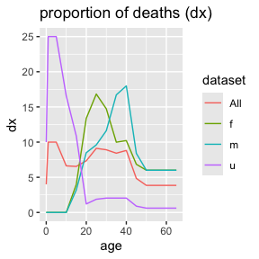

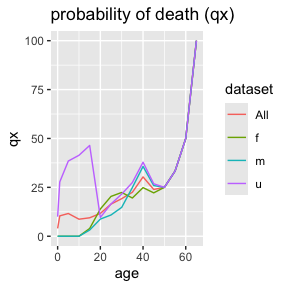

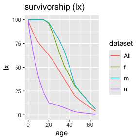

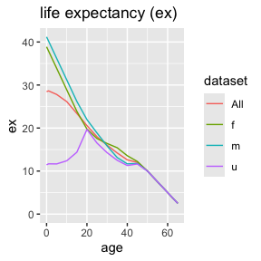

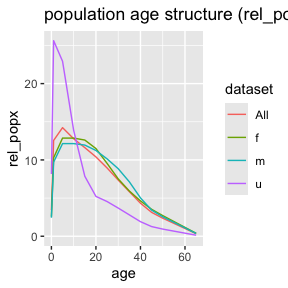

```r
plot(nitra_lt, line_vis = "colour")
```

It is, of course, also possible to address the life tables individually to only display or plot a subset. It is also possible to limit the plots to certain types.

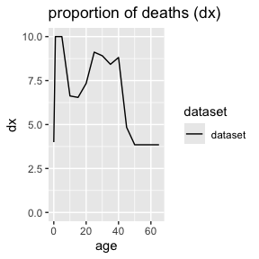

```r
plot(nitra_lt$All, display = "dx")
```

If more control is desired, for example to create customized plots in `ggplot2::ggplot()`, this is also possible. The following takes the life tables from the Nitra example and creates a ggplot diagram with combinations of line types and colours. Please note how the x-axis is created with the column `a` from the life table which contains the length of each age class.

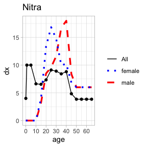

```r
library(ggplot2)
ggplot(nitra_lt$All, aes(x=c(0,cumsum(a)[-nrow(nitra_lt$All)]), y=dx)) +
 geom_point() +
 geom_line(aes(col = "All")) +
 scale_x_continuous(breaks=seq(0, 70, 10)) +
 labs(title="Nitra", x = "age", y = "dx") +
 geom_line(data=nitra_lt$m, aes(col= "male"), linewidth=1.2, linetype="dashed") +
 geom_line(data=nitra_lt$f, aes(col= "female"), linewidth=1.2, linetype="dotted") +
 scale_colour_manual(values = c("black", "blue","red")) + theme_light() +
 theme( legend.title = element_blank())
```

## Going further

Hopefully, the above has succeeded in giving an overview how to use the basic functions of mortAAR. Two further worked examples can be found in the `vignette("example_1")` and `vignette("example_2")`. The former deals especially with data preparation while the latter also covers the use case to combine two life tables in a joined analysis.

More advanced functions of mortAAR deal with testing the representativeness and the subsequent correction of life tables (explained in the `vignette("lt_correction")`) as well as the computation of reproduction indices (`vignette("reproduction")`).